# Introdução à Ciência de Dados

Introdução à Inferência Estatística - Parte 3

Prof. Washington Santos da Silva

IFMG - Campus Formiga

2 de julho de 2025

## Diário de Bordo

**O que vimos até hoje?**

- Aula 1 ✅
  - Introdução e Contextualização ✅
  - O que é Ciência de Dados? ✅
  - Papéis Profissionais na Área de Dados ✅
  - Áreas de Aplicações ✅
  - Habilidades Interpessoais e Analíticas ✅
  - Apresentação da Disciplina ✅
- Aula 2 ✅
  - Metodologia CRISP-DM ✅
  - Tipos de Análise ✅
    - Descritiva ✅
    - Diagnóstica ✅
    - Preditiva ✅
    - Prescritiva ✅
  - Configurações: Git/GitHub ✅
- Aula 3 ✅
  - Introdução ao RStudio ✅
    - Criação do **seu** Projeto RStudio da Disciplina ✅
- Aula 4 ✅
  - Introdução ao Git e GitHub ✅
    - Criação do **seu** repositório do projeto RStudio da disciplina no GitHub ✅
- Aula 5 ✅
  - Breve Revisão do IDE RStudio ✅
  - Introdução ao Sistema de Publicação Quarto ✅
  - Sessão Prática Guiada com Relatório 1 ✅
    - Execução dos comandos git essenciais ✅
- Aula 6 ✅
  - Parte I ✅
    - O Relatório Junglivet e a Metodologia CRISP-DM ✅
    - Primeiro contato com a linguagem R por meio dos códigos do relatório ✅
  - Parte II ✅
    - Para alunos com projetos estruturados ✅
    - Atividade prática ✅
    - Para alunos com dificuldades técnicas ✅
    - Atendimento individualizado para estruturação de projetos ✅
- Aula 7 ✅
  - Introdução ao sistema Quarto (continuação) ✅
    - Gerar relatório no formato pdf ✅
    - Gerar relatório no formato docx ✅
  - Introdução à Linguagem R (continuação) ✅
    - Conceitos: Variáveis e observações ✅
    - Estrutura tabular organizada de dados ✅
    - Tipos e classes de dados principais em R ✅
    - Estruturas de dados: vetores e data frames ✅
- Aula 8 ✅
  - Início do estudo do pacote dplyr para manipulação de dados ✅
    - CRISP-DM: Fase 2 (Entendimento dos dados) e Fase 3 (Preparação dos dados) ✅  
      de um projeto de análise ou ciência de dados ✅
    - O que é o dplyr? ✅
    - A Filosofia *Tidy Data* (Dados Organizados) ✅
    - Dados Organizados (*Tidy Data*) ✅
    - Por que usar o dplyr? ✅
    - Fluxo de trabalho com dplyr ✅
    - Boas Práticas com dplyr ✅
    - Função dplyr::select() ✅
    - Função dplyr::filter() ✅
- Aula 9 ✅
  - Solução dos exercícios práticos sobre as funções select e filter ✅
  - Função dplyr::mutate() ✅
- Aula 10 ✅
  - Soluções dos exercícios práticos sobre a função mutate ✅
  - funções dplyr::group_by(), dplyr::summarize() e dplyr::arrange() ✅
- Aula 11 ✅
  - Metodologia CRISP-DM e Pacote dplyr ✅
  - Revisão sobre Dados Organizados (*Tidy Data*) ✅
  - Exemplos de Dados Desorganizados Comuns em Administração ✅
  - Pacote tidyr: Função pivot_longer ✅
- Aula 12 ✅
  - Metodologia CRISP-DM e o tidyverse ✅
  - Dados Organizados: Potencializando Análises ✅
- Aula 13 ✅
  - Avaliação 1 ✅
- Aula 14 ✅
  - Tipos Básicos de *joins* do pacote dplyr ✅
- Aula 15 ✅
  - Variáveis Aleatórias em Finanças ✅
  - Distribuições de Probabilidade ✅
  - Início: Distribuição Normal (ou Gaussiana) ✅
- Aula 16 ✅
  - Distribuição Normal (ou Gaussiana) - Parte 2 ✅
  - Características da Distribuição de uma VA ✅
    - Valor Esperado (Média) ✅
- Aula 17 ✅
  - Características da Distribuição de uma VA ✅
    - Variância e Desvio-Padrão ✅
    - Variância: Propriedades Básicas ✅
    - Aplicação: Valor-em-Risco (VaR) ✅
    - Assimetria e Curtose ✅
- Aula 18 ✅
  - Características da Distribuição de uma VA ✅
    - Covariância e Correlação ✅
    - Fundamentos de Simulação de Monte Carlo ✅
- Aula 19 ✅
  - Teoria da Probabilidade e Análise Estatística de Dados ✅
  - CRISP-DM e Análise Exploratória de Dados ✅
  - Análise Exploratória Numérica ✅
    - Medidas de Posição (ou de Tendência Central) ✅
    - Medidas de Variabilidade ✅
    - Medidas de Correlação ✅
- Aula 20 ✅
  - Análise Exploratória Gráfica ✅
    - Visualização de Dados e o Pacote ggplot2 ✅
    - Gráficos para Visualizar a Distribuição de Variáveis Numéricas ✅
      - Histograma ✅
      - Densidade Empírica (ou Kernel da Densidade) ✅
      - Boxplot ✅
      - Boxplot Comparativo ✅
- Aula 21 ✅
  - Gráfico Univariado para Variáveis Categóricas:
    - Gráfico de Barras (Barplot)
  - Gráficos Bivariados:
    - Gráficos de Barras Agrupadas e Empilhadas - Variáveis Categóricas
    - Gráfico de Dispersão - Variáveis Numéricas
  - Gráfico para Séries Temporais:
    - Gráfico de Linha Univariado (1 Série Temporal)
    - Gráfico de Linha Bivariado (2 Séries Temporais)
- Aula 22 ✅
  - Lista de Exercícios - Treino para Avaliação 2
- Aula 23 ✅
  - Avaliação 2
- Aula 24 ✅
  - CRISP-DM: Fase 4 - Modelagem/Análise
  - Introdução à Inferência Estatística
    - População e Amostra
    - Amostragem: Conceitos Básicos
    - Parâmetro, Estimador, Estimativa e Estatística
- Aula 25 ✅
  - Distribuição Amostral da Média e Proporção
    - O Problema Central da Inferência Estatística
    - Distribuição Amostral da Média
    - Distribuição Amostral da Proporção
  - Tópico Extra: Interpretação de Gráficos de Séries Temporais

## Nesta Aula

**Tópicos**

## Arquivo para esta Aula (26)

**Instruções**

- Abra o RStudio e o seu Projeto da Disciplina
- Crie a subpasta **15-relatorio** dentro da pasta **relatorios**.
- Acesse o site da disciplina e baixe o arquivo **15-relatorio.zip**
- Descompacte o arquivo, copie/recorte o arquivo `15-relatorio.qmd` e cole dentro da subpasta 14-relatorio.

**Diretrizes para Aulas Mais Produtivas**

🔊 **Mantenha conversas em volume baixo**

⌨️ **Código com método:**

95% dos erros são evitáveis com:

- Atenção na digitação
- Respeitar a sequência lógica de etapas
- Revisão antes de pedir ajuda

🤝 **Inteligência colaborativa:**

- Compartilhe conhecimento
- Resolva questões técnicas simples com colegas próximos
- Reserve ao professor as dúvidas conceituais complexas

💪 **Capacidade de Resolver Problemas**

Cada erro resolvido é uma evolução da sua habilidade analítica

# Estimação por Intervalo de Confiança

## Por que Intervalos de Confiança?

**O Desafio do Analista de Dados**

**Problema**: Uma estimativa pontual informa um valor, mas não quantifica a incerteza associada à inferência de uma amostra para a população.

**Exemplo**: Satisfação média de 7.2 pontos em amostra de 100 clientes.

**Pergunta**: Qual nossa confiança nesta estimativa?

**Solução**: Intervalos de confiança não reduzem a incerteza, mas a expressam de forma probabilisticamente controlada.

**Comunicação Correta**:

> “A satisfação média de todos os clientes está entre 6.8 e 7.6 pontos, com 95% de confiança.”

Quantifica a incerteza da amostragem.

## Importância da Amostragem Aleatória

**Por que a aleatoriedade é importante?**

Os intervalos de confiança assumem que os dados provêm de uma **amostra aleatória** da população de interesse. Esta condição é fundamental para a validade dos resultados.

**Consequências da aleatoriedade**:

- Garante que cada elemento da população tenha chance conhecida de seleção
- Permite que as propriedades probabilísticas dos estimadores sejam válidas
- Assegura que os intervalos tenham as propriedades de cobertura desejadas

**Responsabilidade do analista**: Sempre verificar e documentar o método de amostragem utilizado, alertando sobre limitações quando a aleatoriedade não for garantida.

## Conceito de Intervalo de Confiança

**Definição Formal**

Para uma amostra aleatória $Y = (y_1, y_2, \ldots, y_n)$, um **intervalo de confiança** para um parâmetro $\theta$ é:

$$P[L(Y) \leq \theta \leq U(Y)] = 1 - \alpha$$

Este é um conceito **frequentista**: o parâmetro é fixo, mas os limites do intervalo variam conforme a amostra.

sendo:

- $L(Y)$ = limite inferior de confiança
- $U(Y)$ = limite superior de confiança
- $(1 - \alpha)$ = nível de confiança (0.90, 0.95 ou 0.99)
- $\alpha$ = erro (probabilidade do intervalo não conter o parâmetro da população).

**Fórmula Geral**:
$$\text{Estimativa} \pm \text{Valor Crítico da Dist. Amostral} \times \text{Erro Padrão}$$

**Interpretação**: Se repetíssemos o processo infinitas vezes, $(1-\alpha) \times 100\%$ dos intervalos conteriam o verdadeiro parâmetro.

## Interpretação Correta dos Intervalos

**Cuidado na Interpretação**

**✅ Interpretação Correta**:

“Se repetíssemos o processo de amostragem infinitas vezes, 95% dos intervalos construídos conteriam o verdadeiro parâmetro.”

**❌ Interpretação Incorreta**:

“Há 95% de probabilidade de que o parâmetro esteja neste intervalo específico.”

**Por que a diferença importa?**

O parâmetro populacional é fixo (embora desconhecido). A variabilidade está no método de construção do intervalo, não no parâmetro.

## Interpretação Correta dos Intervalos

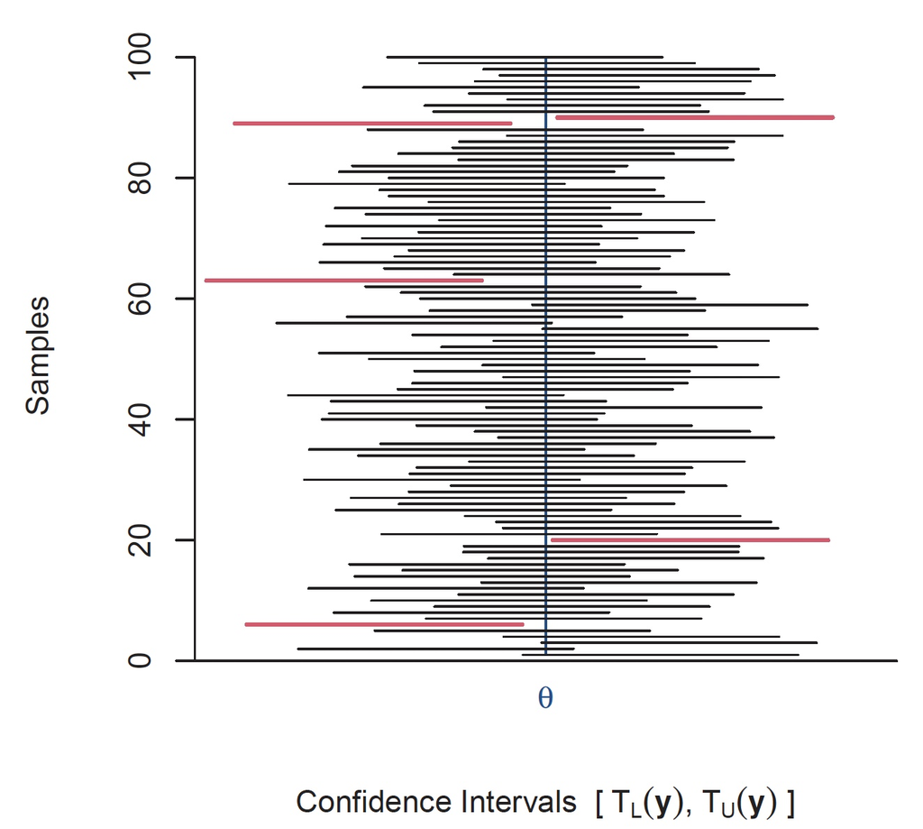

Figura 1: Intervalos de confiança de 95% para um parâmetro $\theta$ com base em 100 amostras separadas de uma população. Os intervalos de confiança em vermelho (5 de 100) são aqueles que não incluem $\theta$.

# Intervalos para Proporções

## Aplicações para Proporções

**Situações Práticas**

**Marketing**: Taxa de conversão, proporção de clientes satisfeitos, percentual de recomendação.

**Qualidade**: Taxa de defeitos, proporção de entregas no prazo, percentual de conformidade.

**Recursos Humanos**: Taxa de rotatividade, percentual de funcionários engajados.

**Pesquisa de Mercado**: Intenção de compra, preferência entre marcas, aceitação de produtos.

**Pesquisas Eleitorais**: Intenção de voto, aprovação de candidatos ou governos.

## IC para Uma Proporção

**Componentes e Fórmula**

| **Elemento** | **Notação** | **Descrição** |
| --- | --- | --- |
| **Parâmetro** | $p$ | Proporção populacional (desconhecida) |
| **Estimador** | $\hat{p} = \frac{x}{n}$ | Proporção amostral observada |
| **Erro Padrão** | $EP(\hat{p}) = \sqrt{\frac{\hat{p}(1-\hat{p})}{n}}$ | Medida da variabilidade do estimador |

**Intervalo de Confiança (método de Wald):**

$$\boxed{
\hat{p} \pm z_{\alpha/2} \sqrt{\frac{\hat{p}(1-\hat{p})}{n}}
}$$

sendo:

- $x$ = número de sucessos observados na amostra
- $n$ = tamanho da amostra
- $z_{\alpha/2}$ = valor crítico da distribuição normal padrão

**Condições de Aplicação:**

- Amostra aleatória da população
- $n\hat{p} \geq 5$ e $n(1-\hat{p}) \geq 5$ (regra prática para validade da aproximação normal)

#### Importante

- A fórmula acima corresponde ao **método de Wald**, uma aproximação baseada na normal.
- A função `prop.test()` de R **não utiliza exatamente essa fórmula**.
- Em vez disso, implementa um intervalo baseado em teste qui-quadrado com correção de continuidade de Yates, o que gera intervalos ligeiramente mais amplos e conservadores, especialmente úteis para proporções próximas de 0 ou 1.

## IC para Diferença entre Duas Proporções

**Comparação Entre Grupos**

| **Elemento** | **Notação** | **Descrição** |
| --- | --- | --- |
| **Parâmetro** | $p_1 - p_2$ | Diferença entre proporções populacionais |
| **Estimador** | $\hat{p}_1 - \hat{p}_2$ | Diferença entre proporções amostrais |
| **Erro Padrão** | $EP = \sqrt{\frac{\hat{p}_1(1-\hat{p}_1)}{n_1} + \frac{\hat{p}_2(1-\hat{p}_2)}{n_2}}$ | Variabilidade da diferença |

**Intervalo de Confiança:**

$$\boxed{(\hat{p}_1 - \hat{p}_2) \pm z_{\alpha/2} \sqrt{\frac{\hat{p}_1(1-\hat{p}_1)}{n_1} + \frac{\hat{p}_2(1-\hat{p}_2)}{n_2}}}$$

sendo:

- $\hat{p}_1 = \frac{x_1}{n_1}$ e $\hat{p}_2 = \frac{x_2}{n_2}$ são as proporções de cada grupo
- $n_1$ e $n_2$ são os tamanhos das amostras dos grupos 1 e 2

**Condições de Aplicação:**

- Amostras aleatórias independentes
- Para cada grupo: $n_i\hat{p}_i \geq 5$ e $n_i(1-\hat{p}_i) \geq 5$

## Funções R para Proporções

**prop.test() e binom.test()**

**`prop.test()`**: Intervalo baseado em teste de hipótese para proporções

- Usa a distribuição **qui-quadrado** com **correção de continuidade de Yates**
- Intervalo é geralmente **mais conservador** do que o método de Wald
- Adequado para amostras grandes ($n \geq 30$)
- Sintaxe: `prop.test(x, n, conf.level = 0.95)`
- Para duas proporções: `prop.test(c(x1, x2), c(n1, n2))`

**`binom.test()`**: Intervalo **exato** com base na distribuição binomial

- Adequado para amostras pequenas ou quando se deseja **precisão máxima**
- Sintaxe: `binom.test(x, n, conf.level = 0.95)`
- Apenas para uma proporção

**Parâmetros comuns**:

- `x`: número de sucessos observados
- `n`: tamanho da amostra
- `conf.level`: nível de confiança (padrão: 0.95)

**Recomendações**:

- Para $n \geq 30$ e proporções longe de 0 ou 1, `prop.test()` é uma escolha prática e confiável
- Para amostras pequenas ou proporções extremas, prefira `binom.test()` para maior precisão

## Exemplo 1: IC para 1 Proporção

**Pesquisa Eleitoral**

**Cenário**: Instituto de pesquisa realiza levantamento sobre intenção de voto para prefeito em cidade de 500.000 habitantes.

**Amostra**: 1.200 eleitores selecionados aleatoriamente **Resultado**: 456 eleitores declararam intenção de votar no Candidato A

**Objetivo**: Estimar a proporção populacional de intenção de voto com intervalo de confiança.

## Exemplo 1 em R

```r
# dados da pesquisa eleitoral
n_eleitores <- 1200
votos_candidato_a <- 456

# estimativa pontual da proporção populacional
# ou simplemente proporção amostral
prop_amostral <- votos_candidato_a / n_eleitores
prop_amostral
```

```
[1] 0.38
```

```r
# Estimativa por Intervalo de confiança (95%) da proporção pop.
estimativa_ic_proporcao <- prop.test(x = votos_candidato_a,
                                 n = n_eleitores,
                                 conf.level = 0.95)

# exibe o resultado
estimativa_ic_proporcao
```

```
    1-sample proportions test with continuity correction

data:  votos_candidato_a out of n_eleitores, null probability 0.5
X-squared = 68.6, df = 1, p-value <0.0000000000000002
alternative hypothesis: true p is not equal to 0.5
95 percent confidence interval:
 0.35255 0.40823
sample estimates:
   p
0.38
```

```r
# extrai somente a estimativa do intervalo de confiança
estimativa_ic_proporcao$conf.int
```

```
[1] 0.35255 0.40823
attr(,"conf.level")
[1] 0.95
```

## Interpretação da Pesquisa Eleitoral

**Resultado e Margem de Erro**

#### Observação Técnica

O intervalo de confiança acima foi obtido com a função `prop.test()` de R, que **não utiliza o método de Wald**.

Em vez disso, usa um método baseado em teste qui-quadrado com correção de continuidade, tornando o intervalo ligeiramente mais conservador**.

Essa diferença ocorre porque a correção busca ajustar o uso da aproximação normal em situações discretas.

## Interpretação da Pesquisa Eleitoral

**Interpretação completa e correta**

**Importante**: A **proporção verdadeira** de eleitores que votarão no Candidato A é **fixa** (embora desconhecida). A **variabilidade está no intervalo**, que muda a cada nova amostra.

**Limitações que deveriam ser reportadas**:

- **Erro de amostragem**: coberto pela margem de erro.
- **Erro de cobertura**: Parte da população pode não ter sido alcançada.
- **Erro de não-resposta**: Eleitores que se recusam a responder.
- **Erro de declaração**: Eleitores que mentem sobre sua intenção.
- **Mudança temporal**: Intenções podem mudar até a eleição.

A **margem de erro tradicional** cobre apenas a **variabilidade associada à amostragem aleatória** — outras fontes de incerteza não estão incluídas.

## Exemplo 2: IC para Diferença entre 2 Proporções

**Análise de Taxa de Conversão**

Uma empresa de e-commerce testou duas estratégias de campanha publicitária digital. O analista de dados precisa comparar as taxas de conversão para determinar se existe diferença significativa entre as estratégias.

**Dados Coletados:**

| Campanha | Visualizações | Conversões | Taxa Observada |
| --- | --- | --- | --- |
| A (Tradicional) | 2.500 | 175 | 7.0% |
| B (Personalizada) | 2.200 | 198 | 9.0% |

**Objetivo da Análise:**

Construir um intervalo de 95% de confiança para a diferença entre as taxas de conversão e avaliar se há evidência estatística de diferença entre as campanhas.

## Exemplo 2 em R

```r
# Dados das campanhas
# Campanha A (Tradicional)
n_a <- 2500
x_a <- 175

# Campanha B (Personalizada)
n_b <- 2200
x_b <- 198

# Calcular proporções amostrais
prop_a <- x_a / n_a
prop_b <- x_b / n_b

# Exibir proporções
prop_a
```

```
[1] 0.07
```

```r
prop_b
```

```
[1] 0.09
```

```r
# Diferença observada (B - A)
diferenca_observada <- prop_b - prop_a
diferenca_observada
```

```
[1] 0.02
```

```r
# Comparar as duas proporções
# A função calcula (primeira - segunda), então usamos ordem (B, A)
# para obter (B - A)
resultado <- prop.test(x = c(x_b, x_a), n = c(n_b, n_a), conf.level = 0.95)

# Exibir resultado completo
resultado
```

```
    2-sample test for equality of proportions with continuity correction

data:  c(x_b, x_a) out of c(n_b, n_a)
X-squared = 6.14, df = 1, p-value = 0.013
alternative hypothesis: two.sided
95 percent confidence interval:
 0.003983 0.036017
sample estimates:
prop 1 prop 2
  0.09   0.07
```

```r
# Extrair intervalo de confiança
ic_a_menos_b <- resultado$conf.int
ic_a_menos_b
```

```
[1] 0.003983 0.036017
attr(,"conf.level")
[1] 0.95
```

## Exemplo 2: Interpretação

**Resultados**

A diferença observada entre as taxas de conversão foi de 2.0 pontos percentuais a favor da Campanha B (9.0% versus 7.0%).

O intervalo de 95% de confiança para a verdadeira diferença indica que, com 95% de confiança, a diferença populacional está entre aproximadamente 0.4 e 3.6 pontos percentuais.

Como o intervalo de confiança não contém zero e todos os valores são positivos, existe evidência estatística de que a Campanha B possui taxa de conversão superior à Campanha A.

## Tipos de Erro em Pesquisas

**Erros Relacionados à Amostragem**

**Erro de Amostragem** (coberto pela margem de erro):

- Variação natural dos resultados ao se usar uma amostra ao invés de um censo. Esse erro é controlável por métodos estatísticos e é o **único** refletido na margem de erro padrão.

**Erro de Cobertura**:

- Ocorre quando parte da população-alvo tem **probabilidade nula ou desigual de seleção**, comprometendo a representatividade da amostra. *Exemplo*: exclusão de pessoas sem celular em pesquisas por telefone.

**Erro de Não-Resposta**:

- Quando há **diferenças sistemáticas entre quem responde e quem não responde**, introduzindo viés nos resultados.

**Implicação**: Mesmo com amostragem aleatória, esses erros podem comprometer a validade da inferência. Devem ser documentados e comunicados sempre que presentes.

## Tipos de Erro em Pesquisas

**Erros na Medição e Análise**

**Erro de Medição**:

- *Instrumento*: Perguntas ambíguas, enviesadas ou mal formuladas, ou ainda influência do entrevistador.
- *Declaração*: Respostas falsas, por pressão social ou desejo de agradar.

**Erro Temporal**:

- Mudanças reais na opinião pública entre a coleta dos dados e o evento de interesse (ex: eleição, lançamento de produto).

**Erro de Processamento**:

- Erros cometidos na entrada, codificação ou análise dos dados.

**Implicação**:

- Esses erros **não são refletidos na margem de erro estatística**, mas podem introduzir vieses significativos.
- A comunicação responsável deve explicitar que a margem de erro cobre **apenas a variabilidade amostral aleatória**.

# Intervalos para Médias

## Aplicações para Médias

**Variáveis Numéricas em Administração**

**Análise Financeira**: Receita média por cliente, valor médio de transações, ROI médio (*com cautela* em caso de assimetrias).

**Operações**: Tempo médio de produção, custo médio unitário, produção média por hora.

**Marketing**: Valor médio de pedidos (ticket médio), tempo médio de conversão, número médio de cliques por campanha.

**Recursos Humanos**: Salário médio por departamento, tempo médio de permanência (retenção).

**Atendimento ao Cliente**: Tempo médio de resposta, pontuação média de satisfação (*em escalas tipo Likert*).

## IC para Uma Média

**Componentes e Fórmula**

| **Elemento** | **Notação** | **Descrição** |
| --- | --- | --- |
| **Parâmetro** | $\mu$ | Média populacional (desconhecida) |
| **Estimador** | $\bar{X} = \frac{1}{n}\sum_{i=1}^{n} X_i$ | Média amostral observada |
| **Erro Padrão** | $EP(\bar{X}) = \frac{s}{\sqrt{n}}$ | Variabilidade da média amostral |

**Intervalo de Confiança (variância desconhecida):**

$$\boxed{
\bar{X} \pm t_{\alpha/2,(n-1)} \times \frac{s}{\sqrt{n}}
}$$

sendo:

- $s$ = desvio padrão amostral
- $n$ = tamanho da amostra
- $t_{\alpha/2,(n-1)}$ = valor crítico da distribuição t com $(n - 1)$ graus de liberdade

**Condições de Aplicação**:

- Amostra aleatória da população
- Dados aproximadamente normais **ou** $n \geq 30$ (Teorema Central do Limite)
- Observações independentes entre si
- Variância populacional **desconhecida** ⇒ uso da distribuição t

## IC para Diferença entre Duas Médias

**Comparação Entre Grupos Independentes**

| **Elemento** | **Notação** | **Descrição** |
| --- | --- | --- |
| **Parâmetro** | $\mu_1 - \mu_2$ | Diferença entre médias populacionais |
| **Estimador** | $\bar{X}_1 - \bar{X}_2$ | Diferença entre médias amostrais |
| **Erro Padrão** | $EP = \sqrt{\frac{s_1^2}{n_1} + \frac{s_2^2}{n_2}}$ | Variabilidade da diferença |

**Intervalo de Confiança (método de Welch):**

$$\boxed{
(\bar{X}_1 - \bar{X}_2) \pm t_{\alpha/2,gl} \times \sqrt{\frac{s_1^2}{n_1} + \frac{s_2^2}{n_2}}
}$$

**Graus de Liberdade (aproximação de Welch):**

$$gl = \frac{\left(\frac{s_1^2}{n_1} + \frac{s_2^2}{n_2}\right)^2}
{\frac{(s_1^2/n_1)^2}{n_1-1} + \frac{(s_2^2/n_2)^2}{n_2-1}}$$

**Condições de Aplicação:**

- Amostras aleatórias e independentes de duas populações
- Dados aproximadamente normais **ou** $n_1, n_2 \geq 30$
- **Não assume variâncias iguais** — este método é mais robusto e é o padrão em `t.test()` no R

## Função t.test() no R

**Ferramenta Principal para Médias**

**t.test()**: Implementa intervalos de confiança e testes t

**Para uma amostra**:

```r
t.test(dados, conf.level = 0.95)
```

**Para duas amostras independentes**:

```r
t.test(grupo1, grupo2, conf.level = 0.95)
```

**Para duas amostras pareadas**:

```r
t.test(antes, depois, paired = TRUE, conf.level = 0.95)
```

**Parâmetros importantes**:

- `conf.level`: nível de confiança (padrão 0.95)
- `var.equal`: assumir variâncias iguais (padrão FALSE, usa correção de Welch)
- `paired`: para amostras pareadas

**Extração de resultados**: Use `resultado$conf.int` para obter apenas o intervalo.

## Verificação de Normalidade com Gráfico QQ

**Como Interpretar um Gráfico Quantil-Quantil**

**Objetivo**: Verificar se os dados seguem distribuição aproximadamente normal.

**Como criar**:

```r
library(ggpubr)
ggqqplot(dados, x = "variavel")
```

**Como interpretar**:

- **Linha diagonal**: distribuição normal teórica
- **Pontos**: quantis observados dos dados
- **Banda cinza**: região de referência baseada em quantis simulados de uma normal — serve como **guia visual**, **não** como intervalo de confiança formal

**Sinais de normalidade adequada**:

- Pontos próximos à linha diagonal
- Maioria dentro da banda cinza
- Padrão aproximadamente linear

**Problemas comuns**:

- Curvaturas (assimetria)
- Padrão em S (caudas pesadas ou leves)
- Muitos pontos fora da banda

**Regra prática**: Para $n \geq 30$, o Teorema Central do Limite garante que pequenas violações da normalidade são aceitáveis.

## Exemplo: Tempo de Resposta de Suporte

**Análise de Atendimento**

**Situação**: Avaliar o tempo médio de resolução de tickets de suporte técnico.

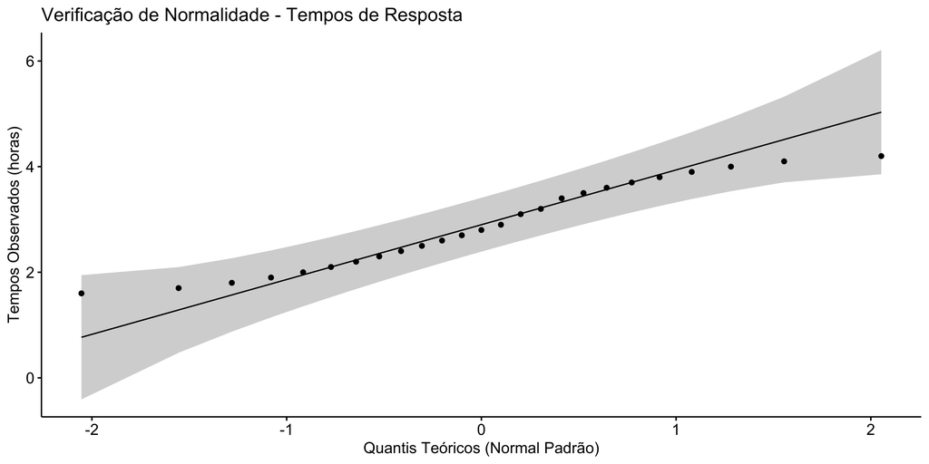

```r
tempos <- c(2.1, 3.4, 1.8, 4.2, 2.9, 3.1, 2.7, 1.9, 3.8, 2.5,
            4.1, 2.3, 3.6, 2.8, 1.7, 3.9, 2.4, 3.2, 2.6, 4.0,
            1.6, 3.5, 2.2, 3.7, 2.0)
dados_tempo <- data.frame(tempo = tempos)

ggqqplot(dados_tempo, x = "tempo") +
  labs(title = "Verificação de Normalidade - Tempos de Resposta",
       x = "Quantis Teóricos (Normal Padrão)",
       y = "Tempos Observados (horas)")
```

O gráfico QQ mostra que os dados estão razoavelmente próximos de uma distribuição normal, com dois pontos no limiar da banda cinza, mas sem grandes desvios.

```r
# média amostral
mean(tempos)
```

```
[1] 2.88
```

```r
# intervalo de confiança
resultado_tempo <- t.test(tempos, conf.level = 0.95)
resultado_tempo$conf.int
```

```
[1] 2.5409 3.2191
attr(,"conf.level")
[1] 0.95
```

**Resultado**: IC 95% = [2.5, 3.2] horas

**Conclusão**: Com 95% de confiança, o tempo médio de resolução está entre **2.5 e 3.2 horas**.

## Aplicação: Testes A/B

**Experimento Controlado**

- **Definição:**

Um teste A/B é um experimento que compara duas estratégias ou abordagens diferentes dividindo aleatoriamente a população-alvo em dois grupos: controle (versão A) e tratamento (versão B).

- **Metodologia:**

Ambas as versões são apresentadas simultaneamente para grupos similares, mantendo constantes todas as demais variáveis. Esta abordagem isola o efeito específico da mudança testada.

- **Prevalência no Mercado Atual:**

Testes A/B tornaram-se prática padrão em empresas digitais e organizações orientadas por dados. Grandes corporações como Google, Amazon, Netflix e Facebook executam milhares de testes A/B simultaneamente para otimizar continuamente suas plataformas e serviços.

- **Exemplos Reais de Aplicação:**

O Netflix testa diferentes thumbnails para filmes e séries para maximizar cliques. O Google experimenta variações na apresentação de resultados de busca para melhorar a experiência do usuário. Empresas de e-commerce testam cores de botões de compra, formulários de checkout e estratégias de frete grátis para aumentar conversões.

- **Análise Estatística:**

Intervalos de confiança para diferença entre proporções ou médias determinam se as diferenças observadas representam efeitos reais ou variação aleatória.

## Exemplo: Teste A/B

**Teste de Duas Versões de Website**

**Cenário**: Comparar tempo médio de permanência entre versão atual (A) e redesenhada (B).

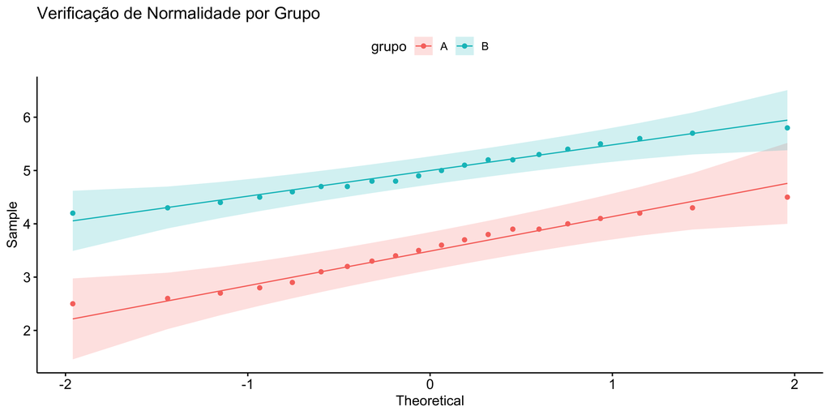

```r
versao_a <- c(3.2, 4.1, 2.8, 3.9, 3.5, 4.3, 2.9, 3.7, 4.0, 3.3,
              2.6, 3.8, 4.2, 3.1, 3.6, 2.7, 4.5, 3.4, 2.5, 3.9)

versao_b <- c(4.8, 5.2, 4.3, 5.6, 4.7, 5.1, 4.9, 5.4, 4.5, 5.0,
              4.6, 5.3, 4.4, 5.7, 4.8, 5.5, 4.2, 5.8, 4.7, 5.2)

dados_ab <- data.frame(
  tempo = c(versao_a, versao_b),
  grupo = c(rep("A", 20), rep("B", 20))
)

ggqqplot(dados_ab, x = "tempo", color = "grupo") +
  labs(title = "Verificação de Normalidade por Grupo")
```

0 gráfico quantil-quantil (QQ) mostra que ambos os grupos estão razoavelmente próximos de uma distribuição normal.

```r
# intervalo de confiança para diferença de médias
resultado_ab <- t.test(versao_b, versao_a, conf.level = 0.95)
resultado_ab$conf.int
```

```
[1] 1.1393 1.8307
attr(,"conf.level")
[1] 0.95
```

**Resultado**: IC 95% para (B - A) = [1.14, 1.83] minutos

**Conclusão**: Com 95% de confiança, a nova versão aumenta o tempo médio de permanência entre **1.14 e 1.83 minutos**.

**Decisão**: Implementar Versão B em produção.

## Síntese: Intervalos de Confiança

**Conceitos Essenciais**

**Fundamento**: Intervalos de confiança quantificam a variabilidade esperada das estimativas obtidas por amostragem, permitindo decisões baseadas em evidência com um grau conhecido de confiabilidade estatística.

**Pré-requisito**: Amostragem aleatória é fundamental. Sem aleatoriedade, as propriedades probabilísticas do intervalo — como a taxa de cobertura de 95% — não são garantidas.

**Métodos por tipo de variável**:

- **Proporções**:
  - `prop.test()` para amostras grandes (usa aproximação normal com correção de continuidade)
  - `binom.test()` para amostras pequenas (método exato, baseado na binomial)
- **Médias**:
  - `t.test()` com base na distribuição t
  - Verificação da normalidade com gráficos QQ ou uso do TCL para $n \geq 30$

**Interpretação correta**:

Se repetíssemos o processo de amostragem muitas vezes, 95% dos intervalos construídos conteriam o parâmetro verdadeiro.

→ A incerteza está no **intervalo**, não no **parâmetro**.

**Comunicação profissional**:

Sempre reportar a estimativa pontual **junto com** o intervalo de confiança e deixar claro que a margem de erro cobre apenas a variabilidade amostral — não erros sistemáticos.

**Limitações importantes**:

Intervalos de confiança cobrem apenas o erro da amostragem aleatória.  
Erros de cobertura, não-resposta e medição também afetam a precisão das estimativas e devem ser considerados na interpretação.

# Exercícios: Intervalos de Confiança

## Exercício 1: Teste A/B

**Análise de Taxa de Cliques em E-mail Marketing**

Uma empresa de varejo online conduziu um teste A/B para avaliar duas versões de e-mail promocional. O analista de dados precisa determinar se existe diferença significativa entre as taxas de cliques das duas versões.

**Dados Coletados:**

Durante uma semana, a empresa enviou aleatoriamente duas versões de e-mail promocional para sua base de clientes:

- Versão A (linha de assunto tradicional): 8.500 e-mails enviados, 612 cliques registrados
- Versão B (linha de assunto personalizada): 8.200 e-mails enviados, 697 cliques registrados

**Questões para Análise:**

1. Estime as taxas de cliques amostrais para cada versão e a diferença observada.
2. Obtenha uma estimativa de um intervalo de 95% de confiança para a diferença entre as taxas de cliques (B - A).
3. Interprete os resultados e faça uma recomendação.

**Instrução:** Utilize a função `prop.test` de R para realizar a análise completa.

## Exercício 2: Tempo de Atendimento

**Avaliação de Dois Métodos de Atendimento ao Cliente**

O departamento de atendimento ao cliente de uma empresa de telecomunicações implementou um novo sistema de triagem automatizada. O gerente de operações deseja comparar o tempo médio de resolução de chamadas entre o método tradicional e o novo sistema automatizado.

**Dados Experimentais:**

Durante um mês, foram coletados aleatoriamente tempos de resolução (em minutos) de chamadas atendidas pelos dois métodos:

```r
# Dados já organizados para facilitar a análise
tradicional <- c(12, 15, 18, 14, 22, 16, 13, 19, 17, 21, 14, 16, 20,
                 18, 15, 23, 17, 14, 19, 16, 18, 15, 20, 17, 16)

automatizado <- c(10, 12, 14, 11, 16, 13, 9, 15, 12, 18, 11, 14, 13,
                  10, 17, 12, 15, 11, 13, 16, 14, 12, 15, 13, 11, 17, 14, 12)

# Cria a data frame para armazenamento dos dados
dados_atendimento <- data.frame(
  tempo = c(tradicional, automatizado),
  metodo = c(rep("Tradicional", length(tradicional)),
             rep("Automatizado", length(automatizado)))
)
```

**Tarefas:**

1. Verifique a normalidade dos dados usando gráficos quantil-quantil
2. Calcule as médias amostrais e desvios padrão de cada método
3. Construa um intervalo de 95% de confiança para a diferença entre os tempos médios
4. Interprete os resultados e faça uma recomendação.

**Instrução:** Utilize a função `ggqqplot()` para verificação de normalidade e `t.test` para estimação por intervalo de confiança.

## Atualizando os Repositórios

**Instruções**

1. No terminal do RStudio, verifique quais arquivos/pastas foram modificados ou criados com:

```bash
git status
```

2. Você pode adicionar todos os arquivos de uma vez com:

```bash
git add .
```

3. Execute git status novamente para confirmar que todos os arquivos foram adicionados (aparecerão em verde sob “*Changes to be committed*”):

```bash
git status
```

4. Se tudo estiver em verde, faça um commit com uma mensagem descritiva:

```bash
git commit -m "atualizacoes aula 26"
```

5. Se algum arquivo ou pasta ainda aparecer em vermelho após o segundo git status, adicione as pastas/arquivos um por um:

```bash
git add relatorios/15-relatorio/15-relatorio.qmd
```

6. Execute git status novamente e faça o commit quando todos os arquivos estiverem em verde:

```bash
git commit -m "atualizacoes aula 26"
```

7. Envie o repositório local atualizado para o GitHub:

```bash
git push origin main
```

## Referências

DEVORE, J. L. **Probabilidade e Estatística para Engenharia e Ciências**. São Paulo: Thomson, 2006.

TRIOLA, M. F. **Introdução à Estatística**. 10. ed. Rio de Janeiro: LTC, 2008.